# Genetic Diversity work

# Load libraries and file paths

```r
library("plyr")
library("dplyr")
library("ggplot2")
library(R.utils)
library(gghighlight)
library(ggman)
library(ggtext)
library(patchwork)
library(plotrix)
library(qqman)
library(qvalue)
library(reshape2)
library(tidyr)
library(zoo)
library(infer)
options(dplyr.summarise.inform = FALSE)
library(bigsnpr)
library("wesanderson")
library("directlabels")
library(OutFLANK)
library(adegenet)
library(poppr)
library(vcfR)
library(stringr)
library(matrixStats)
```

# Nucleotide diversity

Nucleotide diversity (often referred to using the symbol π) is the average pairwise difference between all possible pairs of individuals in your sample. It is a very intuitive and simple measure of genetic diversity, and is accurately estimated even with very few samples. A formal definition is here.

We can obtain the nucleotide diversity (π) from our VCF file using vcftools software. In our case we will collect the π value from each 10 kb (10,000 bp) window of the genome.

NB: vcftools is a very flexible tool for analyzing, manipulating VCF files. It can do many other wonderful things. The vcftools manual is on github here (https://vcftools.sourceforge.net/man_latest.html).

### Breaking up pi by treatment type?

I believe that an important step would be to compare nucleotide diversity between the different treatment groups. The following code present information for all treatment groups and compares it to each individual treatment group.

## Start of modified workflow

## Setup

The following was run on the command line

```bash
# Make ROD_CADO_working directory in home
mkdir ROD_CADO_working
cd ROD_CADO_working
# Make Nucleotide_diversity directory
mkdir ROD_CADO_working
# create popmap file with sample and treatment names
cp /home/Shared_Data/ROD_CADO/analysis/popmap popmap
# manually add in treatment names to popmap file (w/ code)
head treat_popmap
```

C1_2 con-con C1_4 con-con C1_5 con-con C1_6 con-con C1_7 con-con C1_8 con-con C1_9 con-con C2_10 con-con C2_11 con-con C2_2 con-con

# Subsetting popmap groups

Create treatment specific files containing a single column of all of the sample names within that treatment

```bash
awk '$2 == "con-con" {print $1}' treat_popmap > con-con.txt | awk '$2 == "str-con" {print $1}' treat_popmap > str-con.txt | awk '$2 == "con-rod" {print $1}' treat_popmap > con-rod.txt | awk '$2 == "str-rod" {print $1}' treat_popmap > str-rod.txt
```

### Run VCF tools PI window

```r
#bcftools view --threads 20 -S SNP.TRSdp10g1.FIL.vcf | vcftools --vcf -  --window-pi 10000 --out ROD.CADO.all.pi

# For con-con
# Step 1: Filter VCF for population subset
vcftools --gzvcf SNP.TRSdp10g1.FIL.vcf.gz --keep con-con.txt --recode --recode-INFO-all --out temp_concon_filtered

# Step 2: bgzip output
bgzip temp_concon_filtered.recode.vcf

# Step 3: Calculate windowed pi
vcftools --gzvcf temp_concon.filtered.recode.vcf.gz --window-pi 10000 --out ROD.CADO.con-con.pi.windowed.pi

# For str-con
# Step 1: Filter VCF for population subset
vcftools --gzvcf SNP.TRSdp10g1.FIL.vcf.gz --keep popmap_files/str-con.txt --recode --recode-INFO-all --out temp_strcon_filtered

# Step 2: bgzip output
bgzip temp_strcon_filtered.recode.vcf

# Step 3: # Step 3: Calculate windowed pi
vcftools --gzvcf temp_strcon_filtered.recode.vcf.gz --window-pi 10000 --out ROD.CADO.str-con.pi.windowed.pi

# For con-rod
# Step 1: Filter VCF for population subset
vcftools --gzvcf SNP.TRSdp10g1.FIL.vcf --keep popmap_files/con-rod.txt --recode --recode-INFO-all --out temp_conrod_filtered

# Step 2: bgzip output
bgzip temp_conrod_filtered.recode.vcf

# Step 3: Calculate windowed pi
vcftools --gzvcf temp_conrod_filtered.recode.vcf.gz --window-pi 10000 --out ROD.CADO.con-rod.pi.windowed.pi

# For str-rod
# Step 1: Filter VCF for population subset
vcftools --gzvcf SNP.TRSdp10g1.FIL.vcf --keep popmap_files/str-rod.txt --recode --recode-INFO-all --out temp_strrod_filtered

# Step 2: bgzip output
bgzip temp_strrod_filtered.recode.vcf

# Step 3: Calculate windowed pi
vcftools --gzvcf temp_strrod_filtered.recode.vcf.gz --window-pi 10000 --out ROD.CADO.str-rod.pi.windowed.pi
```

### Make loop with help from ChatGPT

#### Make script

```bash
#!/bin/bash

VCF=SNP.TRSdp10g1.FIL.vcf.gz
POPS=("con-con" "str-con" "con-rod" "str-rod")

for POP in "${POPS[@]}"; do
    echo "Processing $POP..."

    KEEP="popmap_files/${POP}.txt"
    OUT_PREFIX="temp_${POP//-}"
    REC_VCF="${OUT_PREFIX}.recode.vcf"
    REC_VCFGZ="${REC_VCF}.gz"
    OUTPUT_PI="ROD.CADO.${POP}.pi.windowed.pi"

    # Step 1: Filter and recode
    vcftools --gzvcf "$VCF" \
        --keep "$KEEP" \
        --recode --recode-INFO-all \
        --out "$OUT_PREFIX"

    # Step 2: Compress VCF and remove uncompressed
    bgzip "$REC_VCF"
    rm "$REC_VCF"

    # Step 3: Calculate windowed pi
    vcftools --gzvcf "$REC_VCFGZ" \
        --window-pi 10000 \
        --out "$OUTPUT_PI"

    # Step 4: Clean up compressed VCF
    rm "$REC_VCFGZ"

    echo "Finished processing $POP"
    echo "---------------------------"
done
```

#### Make executable

```bash
chmod +x run_pi_calculations.sh
```

#### Run in tmux

```bash
# Run in tmux
tmux new -s pi_calc
# Reattach later
tmux attach-session -t pi_calc
```

### Load dataframe

```r
pi.strrod.dataframe<-read.table("/home/jgreen/ROD_CADO_working/Nucleotide_diversity/ROD.CADO.str-cod.pi.windowed.pi.windowed.pi", sep="\t", header=T)
```

```
Error in file(file, "rt") : cannot open the connection
```

### Color palette

```r
#Here is the color pallette that we will use for everything:

col_pal <- c("#0072B2", "#56B4E9", "#E69F00", "#F0E442")

#Let's factor treatments as follows:

df$TREAT <- factor(df$TREAT, levels=c("CONCON", "STRCON", "CONROD", "STRROD"))
```

### Modify CHROM column in dataframe

```r
pi.all.dataframe %>%
  mutate(CHROM = str_replace(CHROM, "NC_035780.1", "1")) %>%
  mutate(CHROM = str_replace(CHROM, "NC_035781.1", "2")) %>%
  mutate(CHROM = str_replace(CHROM, "NC_035782.1", "3")) %>%
  mutate(CHROM = str_replace(CHROM, "NC_035783.1", "4")) %>%
  mutate(CHROM = str_replace(CHROM, "NC_035784.1", "5")) %>%
  mutate(CHROM = str_replace(CHROM, "NC_035785.1", "6")) %>%
  mutate(CHROM = str_replace(CHROM, "NC_035786.1", "7")) %>%
  mutate(CHROM = str_replace(CHROM, "NC_035787.1", "8")) %>%
  mutate(CHROM = str_replace(CHROM, "NC_035788.1", "9")) %>%
  mutate(CHROM = str_replace(CHROM, "NC_035789.1", "10"))  -> pi.all.df
pi.all.df$CHROM <- as.factor(pi.all.df$CHROM)

pi.concon.dataframe %>%
  mutate(CHROM = str_replace(CHROM, "NC_035780.1", "1")) %>%
  mutate(CHROM = str_replace(CHROM, "NC_035781.1", "2")) %>%
  mutate(CHROM = str_replace(CHROM, "NC_035782.1", "3")) %>%
  mutate(CHROM = str_replace(CHROM, "NC_035783.1", "4")) %>%
  mutate(CHROM = str_replace(CHROM, "NC_035784.1", "5")) %>%
  mutate(CHROM = str_replace(CHROM, "NC_035785.1", "6")) %>%
  mutate(CHROM = str_replace(CHROM, "NC_035786.1", "7")) %>%
  mutate(CHROM = str_replace(CHROM, "NC_035787.1", "8")) %>%
  mutate(CHROM = str_replace(CHROM, "NC_035788.1", "9")) %>%
  mutate(CHROM = str_replace(CHROM, "NC_035789.1", "10"))  -> pi.concon.df
pi.concon.df$CHROM <- as.factor(pi.concon.df$CHROM)

pi.conrod.dataframe %>%
  mutate(CHROM = str_replace(CHROM, "NC_035780.1", "1")) %>%
  mutate(CHROM = str_replace(CHROM, "NC_035781.1", "2")) %>%
  mutate(CHROM = str_replace(CHROM, "NC_035782.1", "3")) %>%
  mutate(CHROM = str_replace(CHROM, "NC_035783.1", "4")) %>%
  mutate(CHROM = str_replace(CHROM, "NC_035784.1", "5")) %>%
  mutate(CHROM = str_replace(CHROM, "NC_035785.1", "6")) %>%
  mutate(CHROM = str_replace(CHROM, "NC_035786.1", "7")) %>%
  mutate(CHROM = str_replace(CHROM, "NC_035787.1", "8")) %>%
  mutate(CHROM = str_replace(CHROM, "NC_035788.1", "9")) %>%
  mutate(CHROM = str_replace(CHROM, "NC_035789.1", "10"))  -> pi.conrod.df
pi.conrod.df$CHROM <- as.factor(pi.conrod.df$CHROM)

pi.strcon.dataframe %>%
  mutate(CHROM = str_replace(CHROM, "NC_035780.1", "1")) %>%
  mutate(CHROM = str_replace(CHROM, "NC_035781.1", "2")) %>%
  mutate(CHROM = str_replace(CHROM, "NC_035782.1", "3")) %>%
  mutate(CHROM = str_replace(CHROM, "NC_035783.1", "4")) %>%
  mutate(CHROM = str_replace(CHROM, "NC_035784.1", "5")) %>%
  mutate(CHROM = str_replace(CHROM, "NC_035785.1", "6")) %>%
  mutate(CHROM = str_replace(CHROM, "NC_035786.1", "7")) %>%
  mutate(CHROM = str_replace(CHROM, "NC_035787.1", "8")) %>%
  mutate(CHROM = str_replace(CHROM, "NC_035788.1", "9")) %>%
  mutate(CHROM = str_replace(CHROM, "NC_035789.1", "10"))  -> pi.strcon.df
pi.strcon.df$CHROM <- as.factor(pi.strcon.df$CHROM)

pi.strrod.dataframe %>%
  mutate(CHROM = str_replace(CHROM, "NC_035780.1", "1")) %>%
  mutate(CHROM = str_replace(CHROM, "NC_035781.1", "2")) %>%
  mutate(CHROM = str_replace(CHROM, "NC_035782.1", "3")) %>%
  mutate(CHROM = str_replace(CHROM, "NC_035783.1", "4")) %>%
  mutate(CHROM = str_replace(CHROM, "NC_035784.1", "5")) %>%
  mutate(CHROM = str_replace(CHROM, "NC_035785.1", "6")) %>%
  mutate(CHROM = str_replace(CHROM, "NC_035786.1", "7")) %>%
  mutate(CHROM = str_replace(CHROM, "NC_035787.1", "8")) %>%
  mutate(CHROM = str_replace(CHROM, "NC_035788.1", "9")) %>%
  mutate(CHROM = str_replace(CHROM, "NC_035789.1", "10"))  -> pi.strrod.df
pi.strrod.df$CHROM <- as.factor(pi.strrod.df$CHROM)
```

### For loop to replace previous dataframe manipulation

```r
# Create named vector to map chromosome names
chrom_map <- setNames(as.character(1:10), paste0("NC_03578", 0:9, ".1"))

# List of original dataframe names (as strings)
input_names <- c(
  "pi.all.dataframe",
  "pi.concon.dataframe",
  "pi.conrod.dataframe",
  "pi.strcon.dataframe",
  "pi.strrod.dataframe"
)

# Corresponding output dataframe names
output_names <- c(
  "pi.all.df",
  "pi.concon.df",
  "pi.conrod.df",
  "pi.strcon.df",
  "pi.strrod.df"
)

# Loop through each dataframe
for (i in seq_along(input_names)) {
  df <- get(input_names[i])  # retrieve the dataframe by name

  # Replace chromosome names
  for (old in names(chrom_map)) {
    df <- df %>% mutate(CHROM = str_replace(CHROM, old, chrom_map[[old]]))
  }

  # Convert to factor
  df$CHROM <- as.factor(df$CHROM)

  # Assign to new name in global environment
  assign(output_names[i], df)
}
```

### Descriptive statistics

```r
summary(pi.all.df)
by(pi.all.df, pi.all.df$CHROM, summary)
cor(pi.all.df$N_VARIANTS, pi.all.df$PI)

summary(pi.concon.df)
by(pi.concon.df, pi.concon.df$CHROM, summary)
cor(pi.concon.df$N_VARIANTS, pi.concon.df$PI)

summary(pi.conrod.df)
by(pi.conrod.df, pi.conrod.df$CHROM, summary)
cor(pi.conrod.df$N_VARIANTS, pi.conrod.df$PI)

summary(pi.strcon.df)
by(pi.strcon.df, pi.strcon.df$CHROM, summary)
cor(pi.strcon.df$N_VARIANTS, pi.strcon.df$PI)

summary(pi.strrod.df)
by(pi.strrod.df, pi.strrod.df$CHROM, summary)
cor(pi.strrod.df$N_VARIANTS, pi.strrod.df$PI)
```

### New loop and plotting for statistics

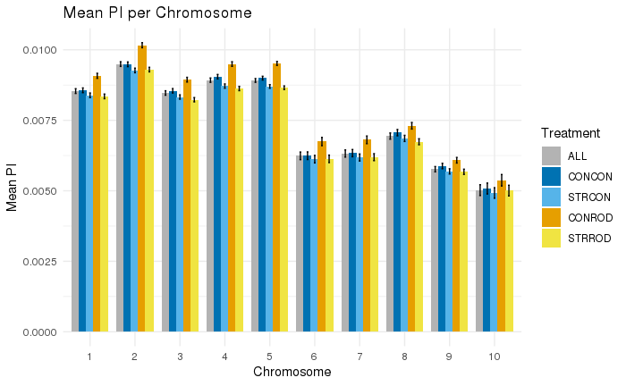

```r
col_pal <- c(
  "ALL" = "gray70",
  "CONCON" = "#0072B2",
  "STRCON" = "#56B4E9",
  "CONROD" = "#E69F00",
  "STRROD" = "#F0E442"
)

df_names <- c("pi.all.df", "pi.concon.df", "pi.strcon.df", "pi.conrod.df", "pi.strrod.df")
df_labels <- c("ALL", "CONCON", "STRCON", "CONROD", "STRROD")
chrom_levels <- as.character(1:10)

summary_list <- list()

for (i in seq_along(df_names)) {
  df <- get(df_names[i])
  treat <- df_labels[i]

  df$TREAT <- factor(treat, levels = names(col_pal))

  chrom_summary <- df %>%
    group_by(CHROM, TREAT) %>%
    summarise(
      mean_PI = mean(PI, na.rm = TRUE),
      se_PI = sd(PI, na.rm = TRUE) / sqrt(n()),
      mean_N_VARIANTS = mean(N_VARIANTS, na.rm = TRUE),
      se_N_VARIANTS = sd(N_VARIANTS, na.rm = TRUE) / sqrt(n()),
      .groups = "drop"
    ) %>%
    mutate(CHROM = factor(CHROM, levels = chrom_levels))

  summary_list[[i]] <- chrom_summary
}

summary_df <- bind_rows(summary_list)

mean_pi_plot <- ggplot(summary_df, aes(x = CHROM, y = mean_PI, fill = TREAT)) +
  geom_bar(stat = "identity", position = position_dodge(width = 0.8)) +
  geom_errorbar(aes(ymin = mean_PI - se_PI, ymax = mean_PI + se_PI),
                position = position_dodge(width = 0.8), width = 0.2) +
  scale_fill_manual(values = col_pal, name = "Treatment") +
  labs(title = "Mean PI per Chromosome", x = "Chromosome", y = "Mean PI") +
  theme_minimal()

mean_n_plot <- ggplot(summary_df, aes(x = CHROM, y = mean_N_VARIANTS, fill = TREAT)) +
  geom_bar(stat = "identity", position = position_dodge(width = 0.8)) +
  geom_errorbar(aes(ymin = mean_N_VARIANTS - se_N_VARIANTS, ymax = mean_N_VARIANTS + se_N_VARIANTS),
                position = position_dodge(width = 0.8), width = 0.2) +
  scale_fill_manual(values = col_pal, name = "Treatment") +
  labs(title = "Mean N_VARIANTS per Chromosome", x = "Chromosome", y = "Mean N_VARIANTS") +
  theme_minimal()

print(mean_pi_plot)
```

```r
print(mean_n_plot)

ggsave("mean_pi_plot.png", plot = mean_pi_plot, width = 10, height = 6, dpi = 300)
```

[figure not shown]

```r
ggsave("mean_n_variants_plot.png", plot = mean_n_plot, width = 10, height = 6, dpi = 300)
```

# Correlation visualizations

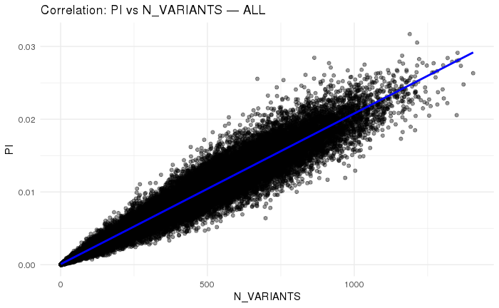

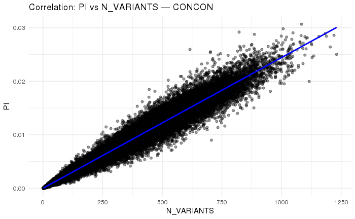

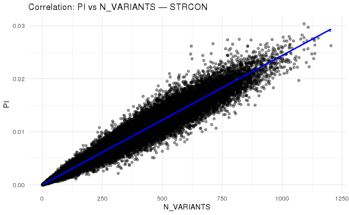

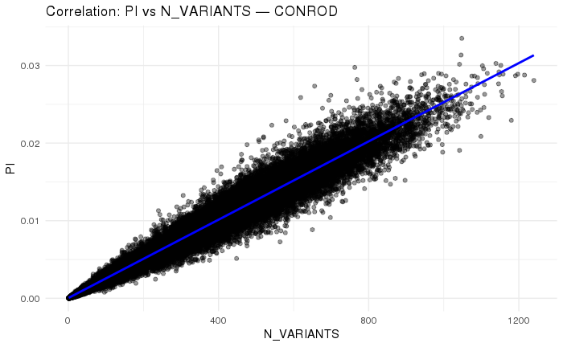

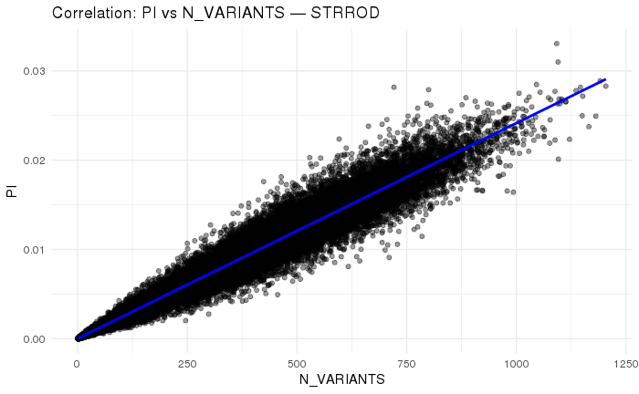

```r
for (i in seq_along(df_names)) {
  df <- get(df_names[i])
  label <- df_labels[i]

  p <- ggplot(df, aes(x = N_VARIANTS, y = PI)) +
    geom_point(alpha = 0.4) +
    geom_smooth(method = "lm", se = FALSE, color = "blue") +
    labs(title = paste("Correlation: PI vs N_VARIANTS —", label),
         x = "N_VARIANTS",
         y = "PI") +
    theme_minimal()

  print(p)
}
```

### Table of correlations

```r
cor_table <- tibble(
  dataset = df_labels,
  correlation = map_dbl(df_names, ~ cor(get(.x)$N_VARIANTS, get(.x)$PI, use = "complete.obs"))
)

print(cor_table)
```

| dataset | correlation |
| --- | --- |
| ALL | 0.9741407 |
| CONCON | 0.9810872 |
| STRCON | 0.9797857 |
| CONROD | 0.9816607 |
| STRROD | 0.9795718 |

### Plot PI by chromosome

```r
ggplot(pi.all.df, aes(x=CHROM, y=PI,))+
  geom_violin(aes(color=CHROM,fill=CHROM))+
  geom_boxplot(aes(fill=CHROM), width=0.1,outlier.shape = 23, outlier.color = "black")+
  stat_summary(fun=mean, geom="point", shape=23, size=2)+
  scale_fill_brewer(palette = "Paired")+
  theme_classic()
```

### Plot PI by chromosome loop

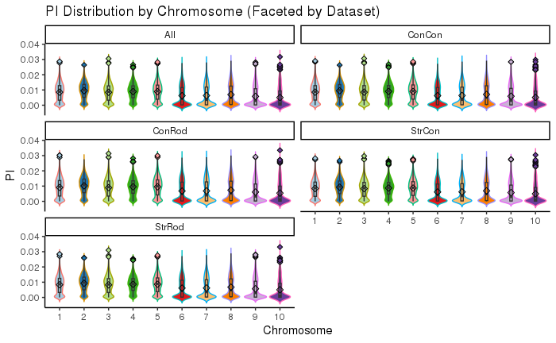

```r
# List of dataframes and labels
df_names <- c("pi.all.df", "pi.concon.df", "pi.conrod.df", "pi.strcon.df", "pi.strrod.df")
df_labels <- c("All", "ConCon", "ConRod", "StrCon", "StrRod")

# Standard chromosome order
chrom_levels <- as.character(1:10)

# Combine all into one dataframe
combined_df <- purrr::map2_dfr(df_names, df_labels, function(df_name, label) {
  df <- get(df_name)
  df %>%
    mutate(
      dataset = label,
      CHROM = factor(CHROM, levels = chrom_levels)
    )
})

# Faceted violin + boxplot
ggplot(combined_df, aes(x = CHROM, y = PI)) +
  geom_violin(aes(color = CHROM, fill = CHROM), trim = FALSE) +
  geom_boxplot(aes(fill = CHROM), width = 0.1, outlier.shape = 23, outlier.color = "black") +
  stat_summary(fun = mean, geom = "point", shape = 23, size = 2) +
  scale_fill_brewer(palette = "Paired") +
  labs(title = "PI Distribution by Chromosome (Faceted by Dataset)",
       x = "Chromosome", y = "PI") +
  facet_wrap(~ dataset, ncol = 2) +
  theme_classic() +
  theme(legend.position = "none")
```

### Smaller visualizations

```r
hist(mydf$PI,br=40)

boxplot(mydf$PI, ylab="Nuc Diversity")
```

### Plot By position

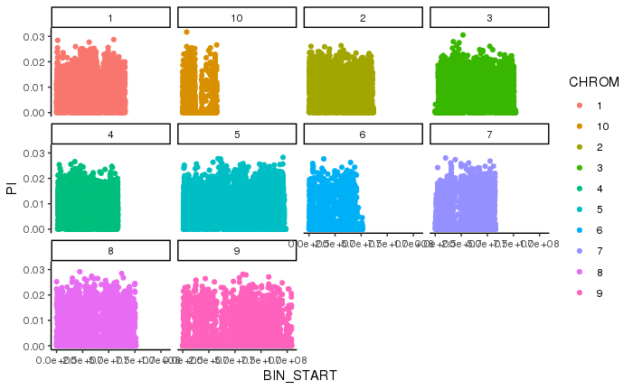

```r
ggplot(pi.all.df, aes(x=BIN_START, y=PI, color=CHROM))+
  geom_point()+
  facet_wrap(~CHROM)+
  theme_classic()
```

### Loop for plot by position

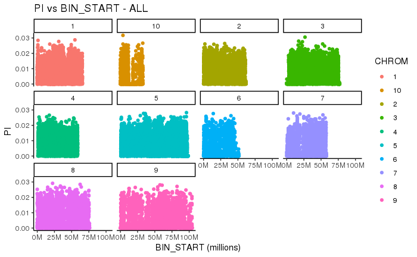

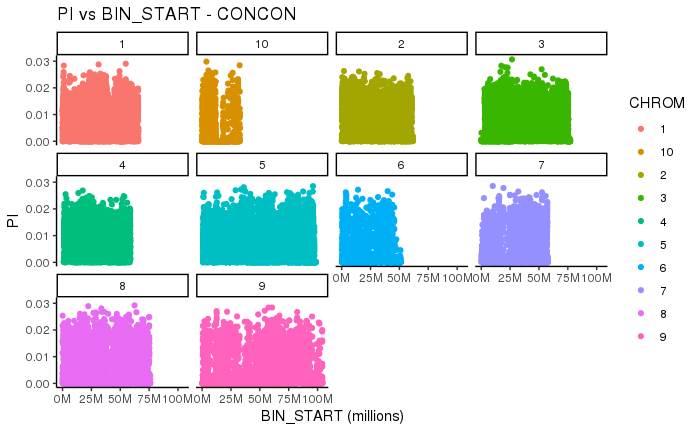

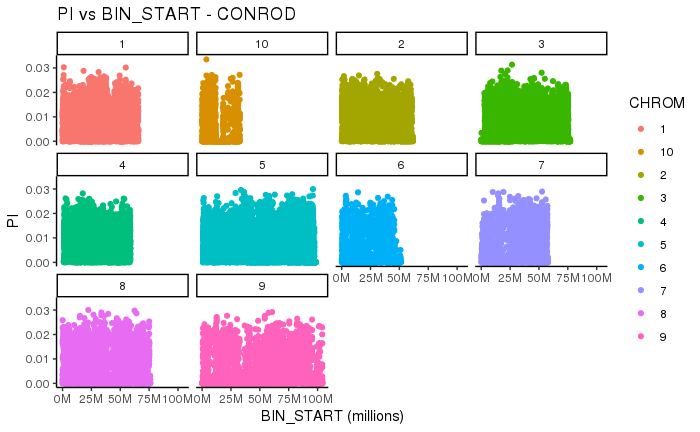

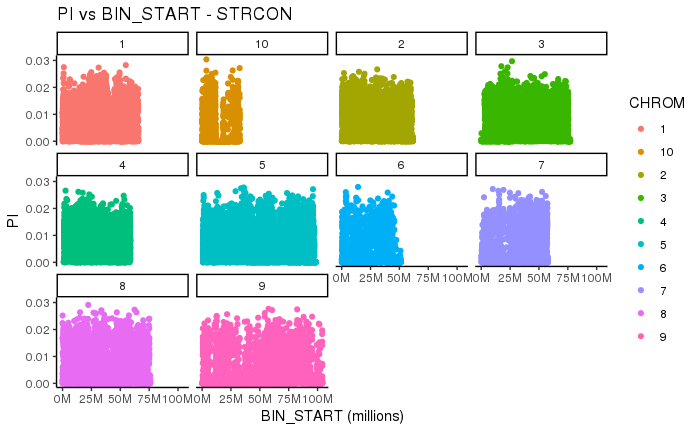

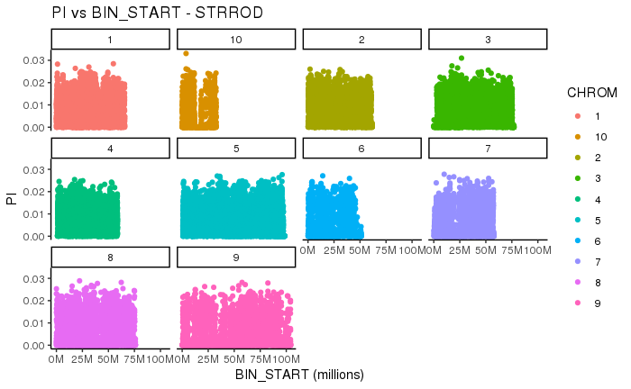

```r
df_names <- c("pi.all.df", "pi.concon.df", "pi.conrod.df", "pi.strcon.df", "pi.strrod.df")
df_labels <- c("ALL", "CONCON", "CONROD", "STRCON", "STRROD")

for (i in seq_along(df_names)) {
  df <- get(df_names[i])
  label <- df_labels[i]

  p <- ggplot(df, aes(x = BIN_START, y = PI, color = CHROM)) +
    geom_point() +
    facet_wrap(~CHROM) +
    scale_x_continuous(labels = label_number(scale = 1e-6, suffix = "M")) +  # Human readable x-axis in millions
    theme_classic() +
    labs(title = paste("PI vs BIN_START -", label),
         x = "BIN_START (millions)",
         y = "PI")

  print(p)

  ggsave(filename = paste0("PI_vs_BIN_START_", label, ".png"),
         plot = p, width = 10, height = 6, dpi = 300)
}
```

### Only chromosome 1

```r
# Subset by chrom
mydf.chr1 <- mydf[which(mydf$CHROM=="1"),]

ggplot(mydf.chr1, aes(x=BIN_START, y=PI))+
  geom_point()+
  theme_classic()
```

```r
# Create an empty list to store the plots
plot_list <- list()

# Loop through chromosomes 1 to 10
for (i in 1:10) {
  chr_data <- mydf[which(mydf$CHROM == as.character(i)), ]

  p <- ggplot(chr_data, aes(x = BIN_START, y = PI)) +
    geom_point() +
    theme_classic() +
    ggtitle(paste("Chromosome", i))

  # Store the plot in the list
  plot_list[[paste0("chr", i)]] <- p
}

# To display one of the plots, for example:
print(plot_list[["chr3"]])
```

# Runs of homozygosity

Runs of homozygosity (ROH) are contiguous lengths of homozygous genotypes that are present in an individual due to parents transmitting identical haplotypes to their offspring.

The potential of predicting or estimating individual autozygosity for a subpopulation is the proportion of the autosomal genome above a specified length, termed Froh.

This technique can be used to identify the genomic footprint of inbreeding in conservation programs, as organisms that have undergone recent inbreeding will exhibit long runs of homozygosity. The effect of inbreeding in the resulting sub-populations could be studied by measuring the runs of homozygosity in different individuals.

## Start ROH workflow

```bash
vcftools --vcf SNP.TRSdp10g1.FIL.vcf --LROH --out ROD.CADO.all.LROH
```